# Pràctica 2

Grup 6

Curs 2024-25

Jordi Lahuerta Reig 1599650  
Roc Grau Piqué 1563847  
Daniel Pons Perán 1603925  
Lucas Poveda Estrada 1597330

### Qualitat de les dades

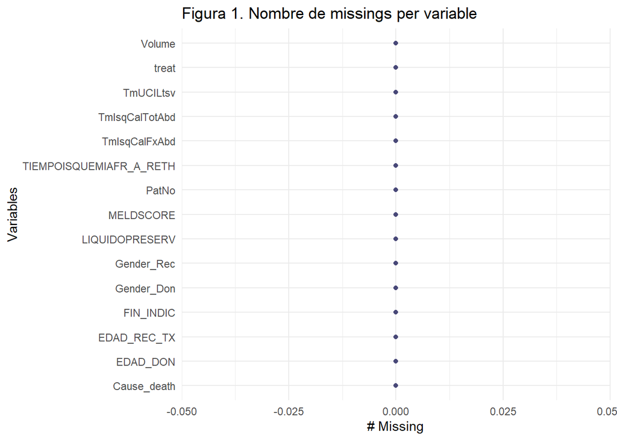

A partir de la *Figura 1* es pot veure com no hi ha valors faltants a cap variable.

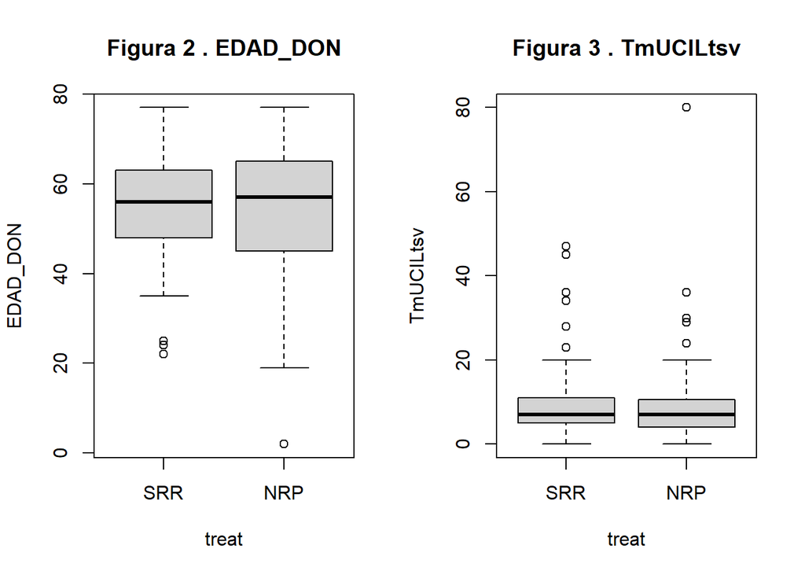

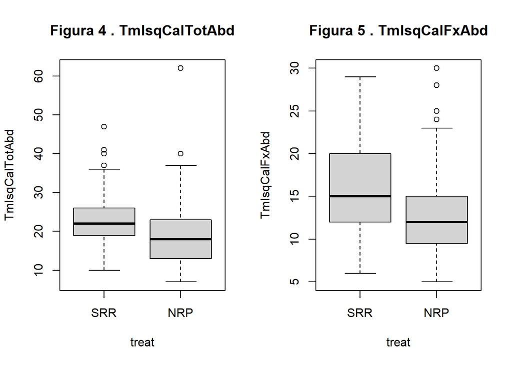

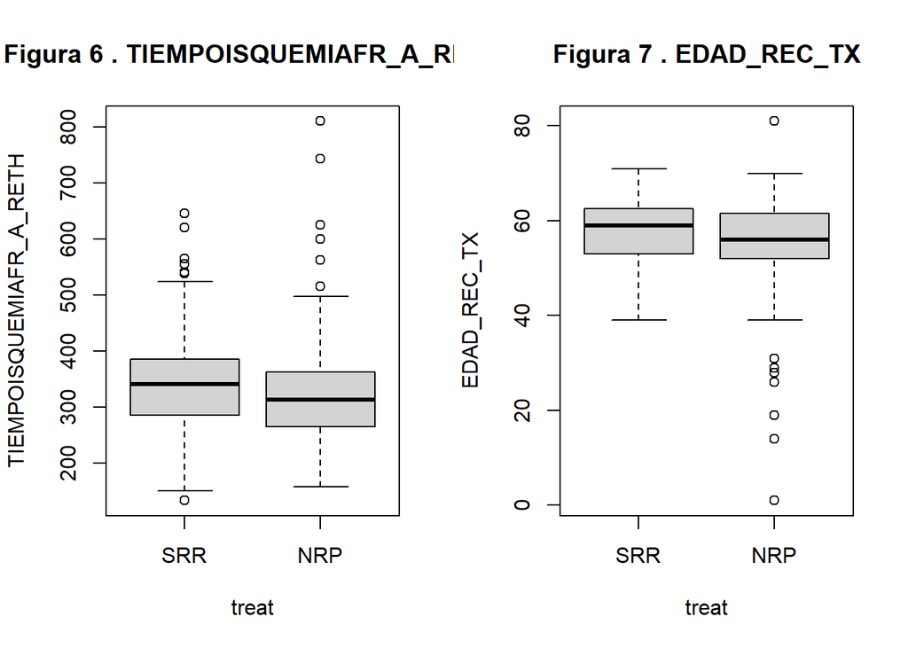

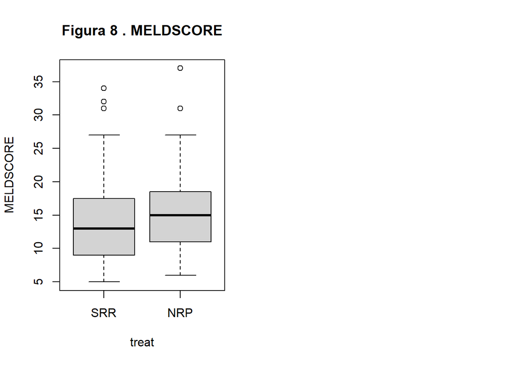

## Análisis amb Inverse Probability of Treatment Weighting (IPTW)

Taula 1. Análisi cru SMD

|  | level | SRR | NRP | p | test | SMD |
| --- | --- | --- | --- | --- | --- | --- |
| n |  | 111 | 91 |  |  |  |
| EDAD_DON (mean (SD)) |  | 54.86 (11.18) | 53.81 (15.28) | 0.573 |  | 0.079 |
| Gender_Don (%) | Female | 36 (32.4) | 31 (34.1) | 0.924 |  | 0.035 |
|  | Male | 75 (67.6) | 60 (65.9) |  |  |  |
| TmUCILtsv (mean (SD)) |  | 9.21 (7.90) | 9.07 (10.02) | 0.911 |  | 0.016 |
| TmIsqCalTotAbd (mean (SD)) |  | 22.95 (6.62) | 18.99 (8.24) | <0.001 |  | 0.530 |
| TmIsqCalFxAbd (mean (SD)) |  | 16.07 (5.28) | 13.13 (5.19) | <0.001 |  | 0.562 |
| TIEMPOISQUEMIAFR_A_RETH (mean (SD)) |  | 341.75 (95.81) | 332.38 (111.46) | 0.522 |  | 0.090 |
| EDAD_REC_TX (mean (SD)) |  | 57.43 (7.15) | 54.84 (12.12) | 0.060 |  | 0.261 |
| Gender_Rec (%) | Female | 15 (13.5) | 20 (22.0) | 0.163 |  | 0.223 |
|  | Male | 96 (86.5) | 71 (78.0) |  |  |  |
| MELDSCORE (mean (SD)) |  | 13.92 (6.15) | 15.22 (6.25) | 0.139 |  | 0.210 |
| Volume (%) | Low | 27 (24.3) | 25 (27.5) | 0.728 |  | 0.072 |
|  | High | 84 (75.7) | 66 (72.5) |  |  |  |
| LIQUIDOPRESERV (%) | CELSIOR | 73 (65.8) | 54 (59.3) | <0.001 |  | 0.989 |
|  | HTK | 27 (24.3) | 1 (1.1) |  |  |  |
|  | UW_IGL1 | 11 (9.9) | 36 (39.6) |  |  |  |
| FIN_INDIC (%) | Cirr | 73 (65.8) | 51 (56.0) | 0.354 |  | 0.253 |
|  | HCC | 34 (30.6) | 33 (36.3) |  |  |  |
|  | Other | 2 (1.8) | 5 (5.5) |  |  |  |
|  | reTx_fulmi | 2 (1.8) | 2 (2.2) |  |  |  |
| Cause_death (%) | Anoxia | 45 (40.5) | 36 (39.6) | 0.989 |  | 0.050 |
|  | CVA | 48 (43.2) | 41 (45.1) |  |  |  |
|  | Other | 7 (6.3) | 6 (6.6) |  |  |  |
|  | TBI | 11 (9.9) | 8 (8.8) |  |  |  |

Mirant la *Taula 1* de les característiques per tractament veiem que només 6 de les 13 varaibles estan equilibrades en els dos tractaments, la resta tenen Standarized Diferences of the Means (SMD) per damunt de 0.1 i algunes arriben ho superen amb creus, com LIQUIDOPRESERV que té una SMD de 0.989. Per tant, sembla clar que fa falta equilibrar els dos grups.

Taula 2. IPTW Análisi

|  | level | SRR | NRP | SMD |
| --- | --- | --- | --- | --- |
| n |  | 102.86 | 91.53 |  |
| EDAD_DON (mean (SD)) |  | 54.41 (11.64) | 53.50 (15.99) | 0.065 |
| Gender_Don (%) | Female | 33.5 (32.5) | 33.5 (36.6) | 0.085 |
|  | Male | 69.4 (67.5) | 58.1 (63.4) |  |
| TmUCILtsv (mean (SD)) |  | 9.04 (7.32) | 9.09 (8.77) | 0.007 |
| TmIsqCalTotAbd (mean (SD)) |  | 22.11 (7.18) | 21.33 (8.05) | 0.102 |
| TmIsqCalFxAbd (mean (SD)) |  | 15.16 (4.98) | 15.01 (6.67) | 0.025 |
| TIEMPOISQUEMIAFR_A_RETH (mean (SD)) |  | 342.72 (91.39) | 349.27 (119.99) | 0.061 |
| EDAD_REC_TX (mean (SD)) |  | 56.76 (7.40) | 55.76 (9.41) | 0.119 |
| Gender_Rec (%) | Female | 18.1 (17.6) | 15.4 (16.8) | 0.020 |
|  | Male | 84.8 (82.4) | 76.1 (83.2) |  |
| MELDSCORE (mean (SD)) |  | 14.73 (7.02) | 14.54 (5.82) | 0.029 |
| Volume (%) | Low | 27.1 (26.4) | 21.4 (23.4) | 0.070 |
|  | High | 75.8 (73.6) | 70.2 (76.6) |  |
| LIQUIDOPRESERV (%) | CELSIOR | 67.2 (65.3) | 59.0 (64.5) | 0.116 |
|  | HTK | 15.4 (15.0) | 11.0 (12.0) |  |
|  | UW_IGL1 | 20.3 (19.7) | 21.5 (23.5) |  |
| FIN_INDIC (%) | Cirr | 66.5 (64.7) | 61.9 (67.6) | 0.123 |
|  | HCC | 32.2 (31.4) | 25.1 (27.4) |  |
|  | Other | 1.6 (1.5) | 2.6 (2.8) |  |
|  | reTx_fulmi | 2.5 (2.5) | 2.0 (2.2) |  |
| Cause_death (%) | Anoxia | 47.1 (45.8) | 46.2 (50.5) | 0.095 |
|  | CVA | 42.5 (41.3) | 34.3 (37.5) |  |
|  | Other | 4.8 (4.7) | 4.1 (4.4) |  |
|  | TBI | 8.5 (8.2) | 6.9 (7.6) |  |

Observant la *Taula 2*, veiem com amb l’IPTW hem aconseguit reduir les diferències entre els dos tractaments. Ara no tenim cap variable per damunt d’una SMD de 0.125 i només 4 superiors a 0.1.

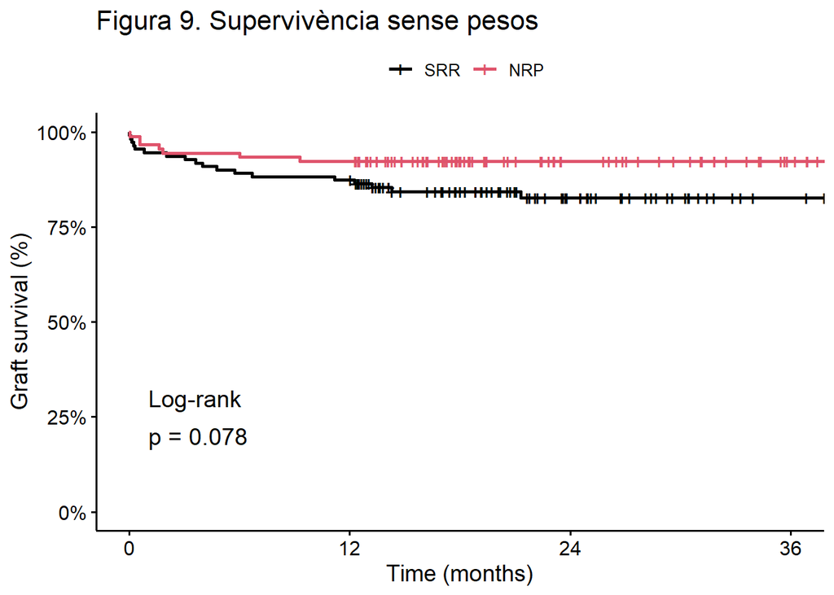

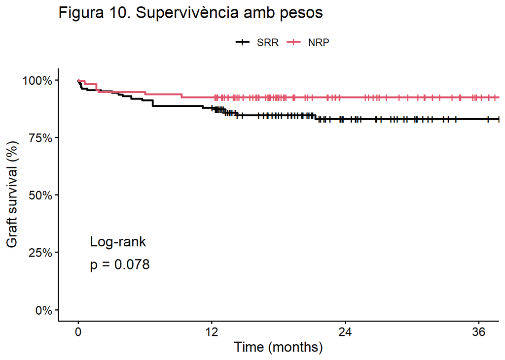

Podem fer el gràfic de Kaplan-Meier tant pel model cru *Figura 9* com per l’ajustat *Figura 10* amb els pesos del PS. Ja que per aplicar l’ajust podem aprofitar els pesos que hem calculat prèviament i s’aplicarant per obtenir una pseudo-mostra balancejada (en cas de no poder fer-ho dins de la funció pots crear manualment el nou dataset balancejat amb els pesos).

Podriem comparar les curves amb el test de Log-Rank i amb el de Cox. De fet, el a l’hora d’observar diferències entre les trajectòries dels dos tractaments el test Log-rank és més robust ja que necessita menys assumpcions.  
Però si volem extreure informació de sobre els riscs només podriem fer-ho amb el de Cox que ens dona el Hazard Ratio. En el nostre cas utilitzarem la el model de Cox per poder avaluar les diferències i els riscs associats.

```
## Call:
## coxph(formula = surv_obj ~ treat, data = baselinedef)
##
##   n= 202, number of events= 25
##
##             coef exp(coef) se(coef)      z Pr(>|z|)
## treatNRP -0.7672    0.4643   0.4455 -1.722   0.0851 .
## ---
## Signif. codes:  0 '***' 0.001 '**' 0.01 '*' 0.05 '.' 0.1 ' ' 1
##
##          exp(coef) exp(-coef) lower .95 upper .95
## treatNRP    0.4643      2.154    0.1939     1.112
##
## Concordance= 0.583  (se = 0.047 )
## Likelihood ratio test= 3.25  on 1 df,   p=0.07
## Wald test            = 2.97  on 1 df,   p=0.09
## Score (logrank) test = 3.11  on 1 df,   p=0.08
```

```
## Call:
## coxph(formula = surv_obj ~ treat, data = baselinedef, weights = IPTW1)
##
##   n= 202, number of events= 25
##
##             coef exp(coef) se(coef) robust se     z Pr(>|z|)
## treatNRP -0.7359    0.4791   0.4533    0.5293 -1.39    0.164
##
##          exp(coef) exp(-coef) lower .95 upper .95
## treatNRP    0.4791      2.087    0.1698     1.352
##
## Concordance= 0.58  (se = 0.059 )
## Likelihood ratio test= 2.85  on 1 df,   p=0.09
## Wald test            = 1.93  on 1 df,   p=0.2
## Score (logrank) test = 2.76  on 1 df,   p=0.1,   Robust = 2.19  p=0.1
##
##   (Note: the likelihood ratio and score tests assume independence of
##      observations within a cluster, the Wald and robust score tests do not).
```

Cap dels dos té valors significatius, encara que el cru està més a prop de ser-ho (si agafessim un nivell de confiança del 90% si que el considerariem significatiu).  
Si ignorem la significació del test (que ens indica que podiren ser diferencies degudes al atzar), veiem que el Hazard Ratio cru i ajustat son molt similars, 0.46 i 0.48 respectivament. Amb aquest valors podriem concloure que NRP resudeix el risc gairebé per damunt d’un 50%.

Per comparar una **variable continua gaussiana** entre els dos grups amb i sense ajust el que faríem seria comparar per la part descriptiva tant la Mitjana com la desviació estàndard de cada un dels grups. En cas ajustat es faria amb aquests paràmetres però ponderats pels pesos obtinguts. Pel que fa a el anàlisis inferencial, el que es podria fer és realitzar un t-test com a prova paramètrica per comparar les mitjanes dels dos grups, al igual que un model lineal. En el cas ajustat, es podria fer un model lineal ajustat amb els pesos IPTW per estimar les diferències de mitjanes ajustades.

Per comparar una **variable continua no gaussiana** entre els dos grups amb i sense ajust el que faríem seria comparar la mediana i el rang interquartílic de cada un dels dos grups. En cas ajustat es faria amb aquests paràmetres però ponderats pels pesos obtinguts. Pel que fa al anàlisi inferencial, es podria fer el test de Mann-Whitney-Wilcoxon el qual és una prova no paramètrica per comparar les distribucions de dues mostres independents on es compara la posició relativa dels valors. En el cas ajustat, es podria fer una regressió dels quantils amb els pesos, on es permet comparar medians ajustats i altres percentils.

Per comparar una **variable binària** entre els dos grups amb i sense ajust el que faríem seria comparar les proporcions en cada un dels dos grups, igual amb els pesos. Pel que fa l’anàlisi inferencial, es podria fer el test chi-quadrat i el test exacte de Fisher. En el cas ajustat, es podria fer una regressió logística generalitzada amb els pesos IPTW i utilitzar el test de Wald per avaluar els coeficients obtinguts al model.

### Análisis amb PS matching (PSM)

Taula 3. Análisi amb PSM

|  | level | SRR | NRP | SMD |
| --- | --- | --- | --- | --- |
| n |  | 50 | 50 |  |
| EDAD_DON (mean (SD)) |  | 54.40 (12.21) | 52.90 (15.40) | 0.108 |
| Gender_Don (%) | Female | 22 (44.0) | 14 (28.0) | 0.338 |
|  | Male | 28 (56.0) | 36 (72.0) |  |
| TmUCILtsv (mean (SD)) |  | 9.18 (7.48) | 7.74 (6.52) | 0.205 |
| TmIsqCalTotAbd (mean (SD)) |  | 21.18 (6.88) | 21.16 (7.12) | 0.002 |
| TmIsqCalFxAbd (mean (SD)) |  | 14.54 (4.05) | 14.20 (5.83) | 0.068 |
| TIEMPOISQUEMIAFR_A_RETH (mean (SD)) |  | 325.40 (89.76) | 340.46 (109.38) | 0.151 |
| EDAD_REC_TX (mean (SD)) |  | 55.56 (7.50) | 56.86 (8.39) | 0.163 |
| Gender_Rec (%) | Female | 9 (18.0) | 8 (16.0) | 0.053 |
|  | Male | 41 (82.0) | 42 (84.0) |  |
| MELDSCORE (mean (SD)) |  | 15.30 (7.44) | 15.58 (6.50) | 0.040 |
| Volume (%) | Low | 13 (26.0) | 14 (28.0) | 0.045 |
|  | High | 37 (74.0) | 36 (72.0) |  |
| LIQUIDOPRESERV (%) | CELSIOR | 37 (74.0) | 36 (72.0) | 0.144 |
|  | HTK | 2 (4.0) | 1 (2.0) |  |
|  | UW_IGL1 | 11 (22.0) | 13 (26.0) |  |
| FIN_INDIC (%) | Cirr | 29 (58.0) | 31 (62.0) | 0.232 |
|  | HCC | 19 (38.0) | 16 (32.0) |  |
|  | Other | 0 (0.0) | 1 (2.0) |  |
|  | reTx_fulmi | 2 (4.0) | 2 (4.0) |  |
| Cause_death (%) | Anoxia | 21 (42.0) | 19 (38.0) | 0.211 |
|  | CVA | 23 (46.0) | 23 (46.0) |  |
|  | Other | 1 (2.0) | 3 (6.0) |  |
|  | TBI | 5 (10.0) | 5 (10.0) |  |

```
## Call:
## coxph(formula = Surv(time = datos_emparejados$DeathTm, event = datos_emparejados$DeathYN) ~
##     treat, data = datos_emparejados)
##
##   n= 100, number of events= 14
##
##             coef exp(coef) se(coef)      z Pr(>|z|)
## treatNRP -0.5835    0.5580   0.5582 -1.045    0.296
##
##          exp(coef) exp(-coef) lower .95 upper .95
## treatNRP     0.558      1.792    0.1868     1.666
##
## Concordance= 0.559  (se = 0.067 )
## Likelihood ratio test= 1.14  on 1 df,   p=0.3
## Wald test            = 1.09  on 1 df,   p=0.3
## Score (logrank) test = 1.12  on 1 df,   p=0.3
```

La principal diferencia d’aques métode respecte el IPTW de la part anterior es la mida mostral. En l’IPTW cada individu té un pes i per tant es manté tota la cohort, pero ponderada; mentre que amb el PSM només s’utilitzen els individus aparellats, per lo que la mostra es pot reduir.

- Pot tenir sentit fer un ajust després del matchin, que tot i que redueix el biaix no garanteix que tots els factors estiguin completament equilibrats: es pot fer una regresió de Cox ajustada per les covariables desequilibrades post-matching
- Les proves inferencials que recomanariem serien un Test de log-rank per a comparar les corbes Kaplan-Meier i també un model de cox post-matching per obtenir un Hazard Ratio ajustat
- Els riscos es calcularien amb el Hazard Ratio a partir de la regresió de Cox. Tambe es podrien estimar els ratis de supervivencia a diferents anys.

Per a comparar variables continues gaussianes s’utilitzarien la mitjana i la desviació estandar. Es realitzaria l’inferencia a partir del test t-student per a mostres aparellades. Podria tenir sentit ajustar després del matching si hi haguess covariables desequilibrades després de fer el matching.

Per a comparar variables continues no gaussianes s’utilitzarien la mediana i el rang interquantilic. Es realitzaria l’inferencia a partir del Wilcoxon signed-rank test. Té sentit fer un ajust post-matching, mitjançant una regressió quantílica o tranformacions, si hi ha desequilibris.

Per a comparar variables binaries s’utilitzarien les proporcions de cada categoria per grup. Per a l’inferencia es faria: test de McNemar o test de chi quadrat / prova de Fisher segons la mida de la mostra. Es podria ajustar mitjançant una regressió logística ajustada, si encara hi hagués confusió.

Respecte del disseny, el disseny de la practica 1 era un disseny de cas-control aparellats (matching tradicional) mentre que la practica 2 es un disseny observacional amb ajust via Propensity Score per controlar el biaix. L’anàlisis a la pràctica 1 era amb un model condicional que controlaba l’aàrellament de forma explícita, mentre que a la pràctica dos hem realitzar l’IPTW per ponderar els individus i PSM per seleccionar una submostra aparellada. Per a l’IPTW/PSM caldria fer un tractament de la dependència perque els parells no són independents. Cal ajustar l’anàlisis inferencial per a tenir-ho en compte: anàlisis robust amb SE robust o potrser models estratificats per les parelles, via regressió.

### Avaluació de l’article (Strobe)

L’article està força bé, tot i que es podrien afegir diferents questions per a millorar-ho:

- Es podría incloure un diagrama del fluxe de pacients, mostrant la selecció, exclusió i seguiment dels pacients
- Es podria explicar que s’ha fet amb les dades faltants, si hi ha hagut
- No es proporciona cap càlcul de la mida de la mostra o del poder estadístic de l’estudi
- No es realitzen anàlisis de interacció o de subgrups, que podrien ser rellevants

## Codi R utilitzat

````r
knitr::opts_chunk$set(echo = FALSE, eval = TRUE, warning = FALSE)
suppressPackageStartupMessages({
library(tidyverse)
library(naniar)
library(tableone)
library(kableExtra)
library(survey)
library(MatchIt)
library(survival)
library(survminer)
})
numeriques<-c("EDAD_DON", "TmUCILtsv", "TmIsqCalTotAbd", "TmIsqCalFxAbd", "TIEMPOISQUEMIAFR_A_RETH", "EDAD_REC_TX", "MELDSCORE")

#llegeixo les dades
baseline<-haven::read_sas(data_file = "baseline.sas7bdat",
                      catalog_file ="formats.sas7bcat" ) %>%
  as.tibble() %>%
  mutate(across(-c(numeriques, PatNo), as.factor))

#passo els dummys dels liquis de preservació a una variable
liquid <- baseline %>%
  pivot_longer(cols = starts_with("LIQUIDOPRESERV_"),
               names_to = "LIQUIDOPRESERV",
               values_to = "value") %>%
  filter(value == 1) %>%
  mutate(LIQUIDOPRESERV = str_remove(LIQUIDOPRESERV, "LIQUIDOPRESERV_")) %>%
  select(LIQUIDOPRESERV)

#faig el mateix amb FIN_INDIC
fin_ind <- baseline %>%
  pivot_longer(cols = starts_with("FIN_INDIC_"),
               names_to = "FIN_INDIC",
               values_to = "value") %>%
  filter(value == 1) %>%
  mutate(FIN_INDIC = str_remove(FIN_INDIC, "FIN_INDIC_")) %>%
  select(FIN_INDIC)

#faig el mateix amb FIN_INDIC
causa_mort <- baseline %>%
  pivot_longer(cols = starts_with("Cause_death_"),
               names_to = "Cause_death",
               values_to = "value") %>%
  filter(value == 1) %>%
  mutate(Cause_death = str_remove(Cause_death, "Cause_death_")) %>%
  select(Cause_death)



#ajunto les dades
nom_fora<-baseline %>% select(starts_with("FIN_INDIC_") | starts_with("LIQUIDOPRESERV_") | starts_with("Cause_death_")) %>% names()

baseline<- baseline %>% select(-all_of(nom_fora)) %>%
  cbind(liquid, fin_ind, causa_mort)


#Canvio el noms dels factors
cols_01 <- names(baseline)[sapply(baseline, is.factor) &
                                     !names(baseline) %in% c("Gender_Don", "Gender_Rec", "Volume", "treat")]


baseline <- baseline %>%
  mutate(across(all_of(cols_01), ~ fct_recode(.x, "No" = "0", "Si" = "1"))) %>%
  mutate(across(c("Gender_Don", "Gender_Rec"), ~ fct_recode(.x, "Female" = "0", "Male" = "1"))) %>%
  mutate(Volume=recode(Volume,"0"="Low", "1"="High"))%>%
  mutate(treat=recode(treat,"0"="SRR", "1"="NRP"))
#mirem per veure que no hi ha missings
#sum(is.na(baseline))
gg_miss_var(baseline)+labs(title = "Figura 1. Nombre de missings per variable")
x<-2
par(mfrow=c(1,2))
for (i in numeriques){
  boxplot(as.formula(paste(i, "~ treat")), data=baseline, main=paste("Figura",x,".",i))
  x<-x+1
}
par(mfrow=c(1,1))
listVar<-names(baseline[-c(1:2)])
TabNoIPTW <- CreateTableOne(vars=listVar ,strata="treat",data=baseline)

print(TabNoIPTW,
      showAllLevels = T,
      smd = TRUE,
      printToggle = F,
      quote = F,
      noSpaces = T) %>%
  kable("html", caption = "Taula 1. Análisi cru SMD") %>%
  kable_styling()

#pas 1

#MODEL 1 - glm(treat ~LIQUIDOPRESERV, data=baseline, family = binomial(link = 'logit'))
#MODEL 2 - glm(treat ~LIQUIDOPRESERV + TmIsqCalFxAbd, data=baseline, family = binomial(link = 'logit'))
#MODEL 3 - glm(treat ~LIQUIDOPRESERV + TmIsqCalFxAbd +EDAD_DON , data=baseline, family = binomial(link = 'logit'))
#MODEL 4 - glm(treat ~LIQUIDOPRESERV + TmIsqCalFxAbd +EDAD_DON + Gender_Rec, data=baseline, family = binomial(link = 'logit'))
#MODEL 5 - glm(treat ~LIQUIDOPRESERV + TmIsqCalFxAbd +EDAD_DON + Gender_Rec +TIEMPOISQUEMIAFR_A_RETH  , data=baseline, family = binomial(link = 'logit'))
#MODEL 6 - glm(treat ~LIQUIDOPRESERV + TmIsqCalFxAbd +EDAD_DON + Gender_Rec +TIEMPOISQUEMIAFR_A_RETH+Cause_death_Anoxia , data=baseline, family = binomial(link = 'logit'))
#MODEL 7 - glm(treat ~LIQUIDOPRESERV + TmIsqCalFxAbd +EDAD_DON + Gender_Rec +TIEMPOISQUEMIAFR_A_RETH + FIN_INDIC  , data=baseline, family = binomial(link = 'logit'))
#MODEL 8 - glm(treat ~LIQUIDOPRESERV + TmIsqCalFxAbd +EDAD_DON + Gender_Rec +TIEMPOISQUEMIAFR_A_RETH + FIN_INDIC+Cause_death_Anoxia  , data=baseline, family = binomial(link = 'logit')) desastre amb anoxia

#MODEL 9 - glm(treat ~LIQUIDOPRESERV + TmIsqCalTotAbd + I(TmIsqCalTotAbd^2)+ TmIsqCalFxAbd  +EDAD_DON + Gender_Rec +TIEMPOISQUEMIAFR_A_RETH + FIN_INDIC +EDAD_REC_TX+Cause_death_CVA   , data=baseline, family = binomial(link = 'logit'))

#MODEL 10 (tots per sota de 0.14) - glm(treat ~LIQUIDOPRESERV + TmIsqCalTotAbd + I(TmIsqCalTotAbd^2)+ TmIsqCalFxAbd  +EDAD_DON + Gender_Rec  +TIEMPOISQUEMIAFR_A_RETH + FIN_INDIC +EDAD_REC_TX  , data=baseline, family = binomial(link = 'logit'))

#MODEL 11 (tots per sota de 0.124) - glm(treat ~ LIQUIDOPRESERV + TmIsqCalTotAbd + I(TmIsqCalTotAbd^2)+ TmIsqCalFxAbd  +EDAD_DON + Gender_Rec  +TIEMPOISQUEMIAFR_A_RETH + FIN_INDIC + log(EDAD_REC_TX) + log(MELDSCORE) , data=baseline, family = binomial(link = 'logit'))

m1<-glm(treat ~ LIQUIDOPRESERV + TmIsqCalTotAbd + I(TmIsqCalTotAbd^2)+ TmIsqCalFxAbd  +EDAD_DON + Gender_Rec  + TIEMPOISQUEMIAFR_A_RETH + FIN_INDIC + log(EDAD_REC_TX) + log(MELDSCORE), data=baseline, family = binomial(link = 'logit'))

#pas 2
baseline1 <- baseline %>%
mutate(prob1 = predict(m1, type = 'response')) %>%
mutate(IPTW1 = case_when(
  treat == "SRR" ~ 0.549505*(1/(1-prob1)),
  treat == "NRP" ~ 0.450495*(1/prob1)
  ))


#pas 3
baselineIPTW1 <- svydesign(ids=~1, data=baseline1, weights=~IPTW1)

## Construct a table (This is a bit slow)
TabIPTW1 <-svyCreateTableOne(vars=listVar, strata="treat", data=baselineIPTW1)

print(TabIPTW1,
      showAllLevels = T,
      smd = TRUE,
      printToggle = F,
      quote = F,
      noSpaces = T,
      test=F) %>%
  kable("html", caption = "Taula 2. IPTW Análisi ") %>%
  kable_styling()
outcomes<-haven::read_sas(data_file = "outcomes.sas7bdat",
                      catalog_file ="formats.sas7bcat" ) %>%
  as.tibble() %>%
  mutate(across(where(haven::is.labelled), ~as.numeric(.x)))
outcomes$PatNo<-as.character(outcomes$PatNo)

baselinedef<- inner_join(baseline1, outcomes, by="PatNo")
surv_obj <- Surv(time = baselinedef$DeathTm, event = baselinedef$DeathYN)

#Kaplan-Meier pel model cru
fit_cru <- survfit(Surv(time = baselinedef$DeathTm, event = baselinedef$DeathYN) ~ treat ,data = baselinedef)

ggsurvplot(fit_cru, xlim= c(0, 36), break.x.by= 12, ylab="Graft survival (%)", xlab= "Time (months)", pval= T, pval.method = T, legend.labs= c("SRR", "NRP"), legend.title="", surv.scale= "percent", palette= c(1,2), risk.table.height= 0.2, title="Figura 9. Supervivència sense pesos")

#Kaplan-Meier pel model ajustat (amb pesos)
fit_pesos <- survfit(Surv(time = baselinedef$DeathTm, event = baselinedef$DeathYN) ~ treat , weight=IPTW1, data = baselinedef)

ggsurvplot(fit_pesos, xlim= c(0, 36), break.x.by= 12, ylab="Graft survival (%)", xlab= "Time (months)", pval= T, pval.method = T, legend.labs= c("SRR", "NRP"), legend.title="", surv.scale= "percent", palette= c(1,2), risk.table.height= 0.2, title="Figura 10. Supervivència amb pesos")
# Modelo de riesgos proporcionales de Cox
#sense pesos
cox_cru <- coxph(surv_obj~treat, data = baselinedef)
summary(cox_cru)

#amb pesos
cox_adj <- coxph(surv_obj~treat, weights = IPTW1, data = baselinedef)
summary(cox_adj)
match_caliper <- matchit(treat ~ LIQUIDOPRESERV + TmIsqCalTotAbd + I(TmIsqCalTotAbd^2)+ TmIsqCalFxAbd  +EDAD_DON + Gender_Rec  +TIEMPOISQUEMIAFR_A_RETH + FIN_INDIC + log(EDAD_REC_TX) + log(MELDSCORE),
data = baselinedef,
method = "nearest",  # matching por vecino más cercano
caliper = 0.2,  # caliper de 0.2 desviaciones estándar
ratio = 1,  # 1:1 matching
replace = FALSE)  # sin reemplazo

datos_emparejados <- match.data(match_caliper)
TabMatch <-CreateTableOne(vars=listVar, strata="treat", data=datos_emparejados)

print(TabMatch,
      showAllLevels = T,
      smd = TRUE,
      printToggle = F,
      quote = F,
      noSpaces = T,
      test=F) %>%
  kable("html", caption = "Taula 3. Análisi amb PSM") %>%
  kable_styling()
# Modelo de riesgos proporcionales de Cox
cox_match <- coxph(Surv(time = datos_emparejados$DeathTm, event = datos_emparejados$DeathYN) ~treat, data = datos_emparejados)
summary(cox_match)
codigo <- unlist(knitr::knit_code$get())

knitr::asis_output(paste0(
  "## Codi R utilitzat\n\n```r\n",
  paste(codigo, collapse = "\n"),
  "\n```"
))
````